# 06 Model Comparison Grp

June 20, 2019

# 1 Overview

The different models and parameterizations have been fit to data from individual participants in the notebook `03_computational_modeling_analysis`. The present notebook contains the model comparison analyses, assessing which model and parameterization best accounts for the intertemporal choices, response times, and framing effects observed across participants. It identifies the models and parameterizations that accounted best for the data overall, and in how many participants each model and parameterization was the best-fitting model.

# 2 Preliminaries

Before reading the data the following is specified:

```r
notebook_name <-
   stringr::str_to_lower(stringr::str_replace_all(params$title, " ", "_"))
```

- the *name of the notebook (`notebook_name`)*, which is used to save output to a notebook-specific directory

```r
# Raw trial log files are read from here
preprocessed_data_dir <-
  file.path("data","derivatives", "01_preprocessing", "included")

# Data from computational modeling will be read from here
modeled_data_dir <-
  file.path("data","derivatives", "03_computational_modeling_analysis", "converged")

# Derivatives will be written here
model_comparison_group_dir <-
  file.path("data","derivatives", notebook_name)

bic_aggregate_winning_model_data_dir <-
  file.path(model_comparison_group_dir, "winning_models_bic_aggregate")

bic_count_winning_model_data_dir <-
  file.path(model_comparison_group_dir, "winning_models_bic_count")

# Figures displaying the first-level computational modeling results are read from here
computational_modeling_idv_figures_dir <-
  file.path("figures", "03_computational_modeling_analysis")

# Figures will be written here
figures_dir <-
  file.path("figures", notebook_name)

# Figures displaying first-level computational modeling results of winning models are copied here
bic_aggregate_winning_model_figures_dir <-
  file.path(figures_dir, "winning_models_bic_aggregate")

bic_count_winning_model_figures_dir <-
  file.path(figures_dir, "winning_models_bic_count")

# Create non-existing dirs if they don't exist
cmdsddfeitc::check_dir(all_dirs = c(preprocessed_data_dir, modeled_data_dir,
                                    model_comparison_group_dir,
                                    bic_aggregate_winning_model_data_dir,
                                    bic_count_winning_model_data_dir,
                                    figures_dir,
                                    bic_aggregate_winning_model_figures_dir,
                                    bic_count_winning_model_figures_dir)
                       )
```

- all *relevant directories* for reading and writing data

```r
# Determine which files should be read
auc_filenames <-
  list.files(path = modeled_data_dir,
             pattern = sprintf("^auc_task-%s.*%s_BIC.*.csv$",
                               params$task[[1]],
                               params$algorithm[[1]]
                               )
             )

optim_stats_filenames <-
  list.files(path = modeled_data_dir,
             pattern = sprintf("^optim_stats_task-%s.*%s_BIC.*.csv$",
                               params$task[[1]],
                               params$algorithm[[1]]
                               )
             )

best_fit_params_filenames <-
  list.files(path = modeled_data_dir,
             pattern = sprintf("best_fitting_params_task-%s.*%s_BIC.*.csv",
                               params$task[[1]],
                               params$algorithm[[1]]
                               )
             )
```

- the *filenames of the files containing the area under the curve data (`auc_filenames`) and optimization statsistics (`optim_stats_filenames`)*

# 3 Read data

Having specified all relevant variables, the AUC data and optimization statistics are read:

```r
# Optimization statistics
optim_stats <- tibble::tibble()

for (i_file in 1:length(optim_stats_filenames)) {
  optim_stats <-
    dplyr::bind_rows(optim_stats,
                     readr::read_csv(file = file.path(modeled_data_dir, optim_stats_filenames[[i_file]]),
                                     col_types = cmdsddfeitc::get_col_types(stringr::str_c("optim_stats_",
                                                                                           params$task)))
                     )
}

# Print for inspection
optim_stats
```

| participant_id | model | parameterization | bound_settings | algorithm | n_iter | converged | LL | AIC | BIC |
| --- | --- | --- | --- | --- | --- | --- | --- | --- | --- |
| 1 | DDM | date_delay_time_and_value_scaling | wide | DEoptimR | 781 | TRUE | -410.9443 | 835.8886 | 857.6725 |
| 1 | DDM | date_delay_time_and_value_scaling_t0 | wide | DEoptimR | 801 | TRUE | -401.5682 | 819.1364 | 844.0323 |
| 1 | DDM | date_delay_time_scaling | wide | DEoptimR | 489 | TRUE | -411.5294 | 835.0588 | 853.7307 |
| 1 | DDM | date_delay_time_scaling_t0 | wide | DEoptimR | 560 | TRUE | -401.5804 | 817.1608 | 838.9447 |
| 1 | DDM | date_delay_value_scaling | wide | DEoptimR | 464 | TRUE | -411.1756 | 834.3513 | 853.0232 |
| 1 | DDM | date_delay_value_scaling_t0 | wide | DEoptimR | 472 | TRUE | -401.5961 | 817.1921 | 838.9760 |
| 1 | DFT_CRT | date_delay_time_and_value_scaling | wide | DEoptimR | 412 | TRUE | -406.8241 | 827.6482 | 849.4321 |
| 1 | DFT_CRT | date_delay_time_and_value_scaling_t0 | wide | DEoptimR | 403 | TRUE | -395.5141 | 807.0283 | 831.9242 |
| 1 | DFT_CRT | date_delay_time_scaling | wide | DEoptimR | 361 | TRUE | -406.8241 | 825.6482 | 844.3201 |
| 1 | DFT_CRT | date_delay_time_scaling_t0 | wide | DEoptimR | 366 | TRUE | -395.5141 | 805.0283 | 826.8122 |

[output cut: 362 more lines]

# 4 Preprocess data

## 4.1 For model comparison purposes

For model comparison purposes, the aggregate BIC value needs to be calculated (if `summary_stat = "aggregate"`) for identifying the best-fitting model overall and the BIC count value needs to be calculated (if `summary_stat = "count"`) to determine how often a model is the best-fitting model per individual.

```r
# ----------------------------------------------------------------------------
compute_model_selection_stat <- function(optim_stats, input_stat = "BIC", summary_stat = "aggregate") {

  # Preliminaries --------------------------------------------------------------
  assertthat::assert_that(input_stat %in% c("AIC", "BIC"),
                          msg = "input_stat can take the following values: 'AIC', 'BIC'.")
  assertthat::assert_that(summary_stat %in% c("aggregate", "count"),
                          msg = "summary_stat can take the following values: 'aggregate', 'count'.")

  summary_stat_key = stringr::str_c(input_stat, summary_stat, sep = "_")
  pmz_levels <- as.character(unique(optim_stats$parameterization))
  model_levels <- as.character(unique(optim_stats$model))


  # Model selection ------------------------------------------------------------

  # 1. Remove participants with missing data (i.e. models that are not fit)
  tidy_optim_stats <-
    optim_stats %>%
    dplyr::select(-bound_settings, -n_iter) %>%
        tidyr::unite(col = "united_col", LL, AIC, BIC, LL) %>%
        tidyr::spread(key = parameterization, value = united_col) %>%
        tidyr::drop_na()

    if (params$task == "defer_speedup") {
      tidy_optim_stats <-
        tidy_optim_stats %>%
        tidyr::gather(key = "parameterization",
                      value = "united_col",
                      pmz_levels,
                      factor_key = TRUE)
    } else if (params$task == "date_delay") {
      tidy_optim_stats <-
        tidy_optim_stats %>%
        tidyr::gather(key = "parameterization",
                      value = "united_col",
                      pmz_levels,
                      factor_key = TRUE)
    }

  tidy_optim_stats <-
    tidy_optim_stats %>%
    tidyr::separate(col = united_col,
                    into = c("LL", "AIC", "BIC"),
                    sep = "_",
                    convert = TRUE)

  # 2. Filter & select relevant model selection (summary) statistics
  if (summary_stat == "count") {

    varname <- paste0("d", input_stat)

    ms_stat_data <-
      tidy_optim_stats %>%
      dplyr::select(participant_id, model, parameterization, !!dplyr::sym(input_stat)) %>%
      dplyr::group_by(participant_id) %>%
      dplyr::arrange(., participant_id, !!dplyr::sym(input_stat)) %>%
      # Compute BIC score relative to best model for each individual: dBIC
      dplyr::mutate(!!varname := !!dplyr::sym(input_stat) - dplyr::first(!!dplyr::sym(input_stat))) %>%
      dplyr::slice(1) %>%
      dplyr::ungroup()


    # Collapsed across models, we're only interested in parameterizations here
    ms_summary_stat_data <-
      ms_stat_data %>%
      dplyr::group_by(participant_id) %>%
      dplyr::slice(1) %>%
      dplyr::ungroup() %>%
      dplyr::group_by(model, parameterization) %>%
      dplyr::summarize(count = n()) %>%
      dplyr::arrange(dplyr::desc(count), model, parameterization) %>%
      dplyr::ungroup() %>%
      tidyr::complete(model, parameterization,
                      fill = list(count = 0))

    } else if (summary_stat == "aggregate") {

      if (input_stat == "AIC") {
        ms_stat_data <-
          tidy_optim_stats %>%
          dplyr::select(participant_id, model, parameterization, AIC)

        ms_summary_stat_data <-
          ms_stat_data %>%
          dplyr::group_by(model, parameterization) %>%
          dplyr::summarize(aggregate_AIC = sum(AIC)) %>%
          dplyr::ungroup() %>%
          dplyr::arrange(aggregate_AIC)

        summary_stat_key <- "aggregate_AIC"

      } else if (input_stat == "BIC") {
        ms_stat_data <-
          tidy_optim_stats %>%
          # Determine number of parameters (k) and data points (n) based on AIC, LL, and BIC, since they weren't stored in optim_stats but are necessary for computing aggregate BIC
          dplyr::mutate(k = round((AIC + 2 * LL) / 2),
                        n = round(exp((BIC + 2 * LL) / k))) %>%
          dplyr::select(-converged)

        ms_summary_stat_data <-
          ms_stat_data %>%
          dplyr::group_by(model, parameterization) %>%
          dplyr::summarize(aggregate_BIC = -2 * sum(LL) + log(sum(n)) * sum(k),
                           k = median(k)) %>%
          dplyr::ungroup() %>%
          dplyr::arrange(aggregate_BIC)

        ms_stat_data <-
          ms_stat_data %>%
          dplyr::select(participant_id, model, parameterization, BIC) %>%
          dplyr::arrange(participant_id, model, parameterization)

        summary_stat_key <- "aggregate_BIC"
      }

      # Retain ms_stat_data from winning model only
      winning_model_and_pmz <-
        ms_summary_stat_data %>%
        dplyr::slice(which.min(!!sym(summary_stat_key)))

      winning_pmz <-
        winning_model_and_pmz %>%
        dplyr::pull(parameterization)
      winning_model <-
        winning_model_and_pmz %>%
        dplyr::pull(model)

      ms_stat_data <-
        ms_stat_data %>%
        dplyr::filter(model == winning_model,
                      parameterization == winning_pmz)
    }

  # Output ---------------------------------------------------------------------
  return(list(ms_stat_data = ms_stat_data,
              ms_summary_stat_data = ms_summary_stat_data)
         )
}
```

Compute aggregate BIC based on individual optimization stats data.

```r
# Get modeling results
modeling_results_bic_aggregate <-
  compute_model_selection_stat(optim_stats,
                               input_stat = "BIC",
                               summary_stat = "aggregate")

# Print for inspection
modeling_results_bic_aggregate$ms_summary_stat_data
```

| model | parameterization | aggregate_BIC | k |
| --- | --- | --- | --- |
| DFT_CRT | date_delay_time_scaling | 22430.32 | 6 |
| DFT_CRT | date_delay_value_scaling | 22483.32 | 6 |
| DFT_CRT | date_delay_time_scaling_t0 | 22525.11 | 7 |
| DFT_CRT | date_delay_value_scaling_t0 | 22537.10 | 7 |
| DFT_CRT | date_delay_time_and_value_scaling | 22734.66 | 7 |
| DFT_CRT | date_delay_time_and_value_scaling_t0 | 22789.43 | 8 |
| DDM | date_delay_value_scaling | 23335.37 | 6 |
| DDM | date_delay_value_scaling_t0 | 23360.05 | 7 |
| DDM | date_delay_time_scaling_t0 | 23395.04 | 7 |
| DDM | date_delay_time_scaling | 23430.04 | 6 |

[output cut: 2 more lines]

Count how often a model and parameterization has the lowest BIC value across participants based on optimization stats data.

```r
# Get modeling results
modeling_results_bic_count <-
  compute_model_selection_stat(optim_stats,
                               input_stat = "BIC",
                               summary_stat = "count")

# Print for inspection
modeling_results_bic_count$ms_summary_stat_data
```

| model | parameterization | count |
| --- | --- | --- |
| DDM | date_delay_time_and_value_scaling | 1 |
| DDM | date_delay_time_and_value_scaling_t0 | 0 |
| DDM | date_delay_time_scaling | 1 |
| DDM | date_delay_time_scaling_t0 | 3 |
| DDM | date_delay_value_scaling | 3 |
| DDM | date_delay_value_scaling_t0 | 2 |
| DFT_CRT | date_delay_time_and_value_scaling | 0 |
| DFT_CRT | date_delay_time_and_value_scaling_t0 | 0 |
| DFT_CRT | date_delay_time_scaling | 10 |
| DFT_CRT | date_delay_time_scaling_t0 | 5 |

[output cut: 2 more lines]

## 4.2 For visualization purposes

For visualization purpuses, the data needs to be made human readable and factorized and a $\Delta BIC$ value (`dBIC`) needs to be computed, reflecting the difference in BIC value between the best-fitting model and other models.

```r
# Greens
fill_values <- c("#ccece6", "#99d8c9", "#66c2a4", "#2ca25f", "#006d2c")

# Preprocess modeling data for visualization

model_selection_data_for_plotting <-
  dplyr::left_join(modeling_results_bic_aggregate$ms_summary_stat_data,
                   modeling_results_bic_count$ms_summary_stat_data,
                   by = c("model", "parameterization")) %>%
  dplyr::arrange(model, parameterization) %>%
  dplyr::mutate(dBIC = aggregate_BIC - min(aggregate_BIC),
                model = forcats::fct_relabel(.$model, .fun = cmdsddfeitc::relabel_mdl),
                parameterization = forcats::fct_reorder(forcats::fct_relabel(.$parameterization,
                                                                             .fun = cmdsddfeitc::relabel_pmz),
                                                        .x = as.integer(as.character(.$k)),
                                                        .fun = sum,
                                                        .desc = TRUE),
                count = as.integer(count),
                k = as.factor(k)
                )

# Print for inspection
model_selection_data_for_plotting
```

| model | parameterization | aggregate_BIC | k | count | dBIC |
| --- | --- | --- | --- | --- | --- |
| DDM (σ fixed) | κ μ | 23611.67 | 7 | 1 | 1181.34848 |
| DDM (σ fixed) | κ μ t0 | 23658.63 | 8 | 0 | 1228.31384 |
| DDM (σ fixed) | κ | 23430.04 | 6 | 1 | 999.71640 |
| DDM (σ fixed) | κ t0 | 23395.04 | 7 | 3 | 964.71485 |
| DDM (σ fixed) | μ | 23335.37 | 6 | 3 | 905.05006 |
| DDM (σ fixed) | μ t0 | 23360.05 | 7 | 2 | 929.72567 |
| DFT (σ varied) | κ μ | 22734.66 | 7 | 0 | 304.34203 |
| DFT (σ varied) | κ μ t0 | 22789.43 | 8 | 0 | 359.10918 |
| DFT (σ varied) | κ | 22430.32 | 6 | 10 | 0.00000 |
| DFT (σ varied) | κ t0 | 22525.11 | 7 | 5 | 94.78646 |

[output cut: 2 more lines]

# 5 Analyze data

The best-fitting model overall is identified by sorting the models and parameterizations based on aggregate BIC.

Table 5.1 ranks the models and parameterizations from best- to worst-fitting, based on aggregate BIC score. Lower BIC indicates a better balance between goodness-of-fit and model complexity, hence a more desirable model.

```r
knitr::kable(
  modeling_results_bic_aggregate$ms_summary_stat_data %>%
  dplyr::arrange(aggregate_BIC),
  booktabs = TRUE,
  caption = 'Model comparison based on aggregate BIC, sorted from best- to worst-fitting.'
)
```

Table 5.1: Model comparison based on aggregate BIC, sorted from best- to worst-fitting.

| model | parameterization | aggregate_BIC | k |
| --- | --- | --- | --- |
| DFT_CRT | date_delay_time_scaling | 22430.32 | 6 |
| DFT_CRT | date_delay_value_scaling | 22483.32 | 6 |
| DFT_CRT | date_delay_time_scaling_t0 | 22525.11 | 7 |
| DFT_CRT | date_delay_value_scaling_t0 | 22537.10 | 7 |
| DFT_CRT | date_delay_time_and_value_scaling | 22734.66 | 7 |
| DFT_CRT | date_delay_time_and_value_scaling_t0 | 22789.43 | 8 |
| DDM | date_delay_value_scaling | 23335.37 | 6 |
| DDM | date_delay_value_scaling_t0 | 23360.05 | 7 |
| DDM | date_delay_time_scaling_t0 | 23395.04 | 7 |
| DDM | date_delay_time_scaling | 23430.04 | 6 |
| DDM | date_delay_time_and_value_scaling | 23611.67 | 7 |
| DDM | date_delay_time_and_value_scaling_t0 | 23658.63 | 8 |

Table 5.2 ranks the models and parameterizations from most to least frequent best-fitting.

```r
knitr::kable(
  modeling_results_bic_count$ms_summary_stat_data %>%
    dplyr::arrange(dplyr::desc(count)),
  booktabs = TRUE,
  caption = 'Model comparison based on BIC coun, sorted from most- to least-frequent best-fitting.'
)
```

Table 5.2: Model comparison based on BIC coun, sorted from most- to least-frequent best-fitting.

| model | parameterization | count |
| --- | --- | --- |
| DFT_CRT | date_delay_time_scaling | 10 |
| DFT_CRT | date_delay_time_scaling_t0 | 5 |
| DDM | date_delay_time_scaling_t0 | 3 |
| DDM | date_delay_value_scaling | 3 |
| DFT_CRT | date_delay_value_scaling | 3 |
| DFT_CRT | date_delay_value_scaling_t0 | 3 |
| DDM | date_delay_value_scaling_t0 | 2 |
| DDM | date_delay_time_and_value_scaling | 1 |
| DDM | date_delay_time_scaling | 1 |
| DDM | date_delay_time_and_value_scaling_t0 | 0 |
| DFT_CRT | date_delay_time_and_value_scaling | 0 |
| DFT_CRT | date_delay_time_and_value_scaling_t0 | 0 |

# 6 Visualize data

Figure 6.1 shows two plots:

- The left plot depicts $\Delta BIC$ for all models and parameterizations, with the best-fitting model having $\Delta BIC = 0$.
- The right plot shows for all models and parameterizations in how many participants these fit the data best.

```r
# Make plot of model comparison based on aggregate BIC
plt_aggregate_bic <-
  cmdsddfeitc::plot_model_comparison_aggregate_bic(tibb = model_selection_data_for_plotting,
                                                   fill_values = fill_values)

# Make plot of model comparison based on BIC count
plt_bic_count <-
  cmdsddfeitc::plot_model_comparison_bic_count(tibb = model_selection_data_for_plotting,
                                               fill_values = fill_values)
```

The two plots are the assembled into one figure with a common legend.

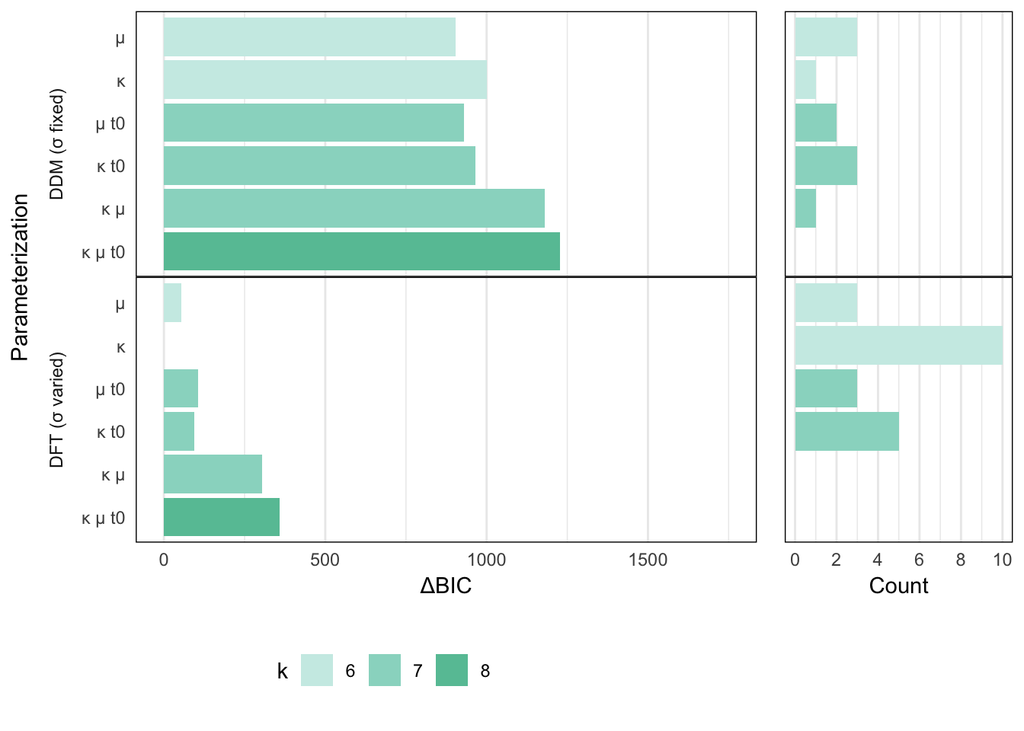

Figure 6.1: Model comparison results for the date-delay task. Left: $\Delta BIC$ values for drift-diffusion models with fixed $\sigma$ (top panel) and decision field theory models with varied $\sigma$ (bottom panel) and different parameterizations (rows inside a panel indicates parameters that were free to vary between frames: $\mu$, scaling parameter of the value function; $\kappa$, scaling parameter of the time function; $t0$, nondecision time parameter). Right: Number of participants in which the respective model and parameterization was the best-fitting model. Color is mapped onto the number of free parameters (k).

```r
lgnd <- cowplot::get_legend(plt_aggregate_bic + ggplot2::theme(legend.position = "bottom",
                                                      legend.direction = "horizontal",
                                                      legend.box = "vertical"))

plt_model_comparison <- cowplot::plot_grid(plt_aggregate_bic + theme(legend.position="none"),
                                           plt_bic_count + theme(legend.position="none"),
                                           lgnd,
                                           align = "hv",
                                           rel_widths = c(3,1),
                                           rel_heights = c(1,.2))

# Caption text
cap_model_comparison <-
  sprintf("Model comparison results for the %s task. Left: $\\Delta BIC$ values for drift-diffusion models with fixed $\\sigma$ (top panel) and decision field theory models with varied $\\sigma$ (bottom panel) and different parameterizations (rows inside a panel indicates parameters that were free to vary between frames: $\\mu$, scaling parameter of the value function; $\\kappa$, scaling parameter of the time function; $t0$, nondecision time parameter). Right: Number of participants in which the respective model and parameterization was the best-fitting model. Color is mapped onto the number of free parameters (k).",
                  stringr::str_replace(params$task, pattern = "_", replacement = "-")
                  )

plt_model_comparison
```

# 7 Write data

## 7.1 Symlinks to participant-level data and figures of winning model

Symlinks are created to participant-level data and figures of the winning models and parameterizations. This is done for easy selection of data in subsequent notebooks and inspection of results.

```r
# Define function for making symbolic links ====================================

make_sym_links_to_best_mdl_files <- function(tibb, src_dir, tgt_dir, file_type = "data") {

  # Formatted string, for selecting files
  if (file_type == "data") {
    fmt <- ".*_task-%s_pid-%.3d_model-%s_pmz-%s_bounds.*_algorithm-DEoptimR.*.csv"
  } else if (file_type == "plot") {
    fmt <- "^plot.*_task-%s_pid-%.3d_model-%s_pmz-%s_bounds.*_algorithm-DEoptimR.*"
  }

  # Loop over rows
  for (i_row in 1:nrow(tibb)) {

    # Identify participant ID, model, and parameterization -----------------------
    pid <- tibb[i_row,]$participant_id
    mdl <- as.character(tibb[i_row,]$model)
    # Strip task from parameterization string
    pmz <- stringr::str_replace(string = tibb[i_row,]$parameterization,
                                pattern = paste0(params$task,"_"),
                                replacement = "")

    # Select files ---------------------------------------------------------------
    winning_model_files <-
      list.files(path = src_dir,
                 pattern = sprintf(fmt, params$task[[1]], pid, mdl, pmz)
                 )

    # Make a symbolic link -------------------------------------------------------
    purrr::pmap(.l = list(fn = winning_model_files),
                .f = function(fn, src_dir, tgt_dir) {
                  fs::link_create(path = fs::path_abs(fs::path(src_dir, fn)),
                                  new_path = fs::path_abs(fs::path(tgt_dir, fn)),
                                  symbolic = TRUE)
                },
                src_dir = src_dir,
                tgt_dir = tgt_dir)
  }
}
```

Copy data of winning models to a new directory

```r
# Based on aggregate BIC
make_sym_links_to_best_mdl_files(tibb = modeling_results_bic_aggregate$ms_stat_data,
                                 src_dir = modeled_data_dir,
                                 tgt_dir = bic_aggregate_winning_model_data_dir,
                                 file_type = "data")

# Based on BIC count
make_sym_links_to_best_mdl_files(tibb = modeling_results_bic_count$ms_stat_data,
                                 src_dir = modeled_data_dir,
                                 tgt_dir = bic_count_winning_model_data_dir,
                                 file_type = "data")
```

Copy images of winning model to a new directory

```r
# Based on aggregate BIC
make_sym_links_to_best_mdl_files(tibb = modeling_results_bic_aggregate$ms_stat_data,
                                 src_dir = computational_modeling_idv_figures_dir,
                                 tgt_dir = bic_aggregate_winning_model_figures_dir,
                                 file_type = "plot")

# Based on BIC counts
make_sym_links_to_best_mdl_files(tibb = modeling_results_bic_count$ms_stat_data,
                                 src_dir = computational_modeling_idv_figures_dir,
                                 tgt_dir = bic_count_winning_model_figures_dir,
                                 file_type = "plot")
```

Save the data underlying the model comparison plot

```r
# Make file name human- and machine-readable, so that main results can be read from file name
model_comparison_plot_data_file <-
  file.path(model_comparison_group_dir,
            sprintf("model_comparison_plot_data_task-%s.csv",
                    params$task
                    )
            )

readr::write_csv(model_selection_data_for_plotting,
                 path = model_comparison_plot_data_file
            ) %>%
print(sprintf("%s", model_comparison_plot_data_file))
```

```
## # A tibble: 12 x 6
##    model          parameterization aggregate_BIC k     count   dBIC
##    <chr>          <chr>                    <dbl> <chr> <int>  <dbl>
##  1 DDM (σ fixed)  κ μ                     23612. 7         1 1181.
##  2 DDM (σ fixed)  κ μ t0                  23659. 8         0 1228.
##  3 DDM (σ fixed)  κ                       23430. 6         1 1000.
##  4 DDM (σ fixed)  κ t0                    23395. 7         3  965.
##  5 DDM (σ fixed)  μ                       23335. 6         3  905.
##  6 DDM (σ fixed)  μ t0                    23360. 7         2  930.
##  7 DFT (σ varied) κ μ                     22735. 7         0  304.
##  8 DFT (σ varied) κ μ t0                  22789. 8         0  359.
##  9 DFT (σ varied) κ                       22430. 6        10    0
## 10 DFT (σ varied) κ t0                    22525. 7         5   94.8
## 11 DFT (σ varied) μ                       22483. 6         3   53.0
## 12 DFT (σ varied) μ t0                    22537. 7         3  107.
```

## 7.2 Figures

Finally, the figures are witten to disk in raster and vector format.

```r
# General parameters ===========================================================

# Resolution
dpi <- 300
```

```r
# Filename
fn <- sprintf("model_comparison_results-%s_dpi-%d", params$task, dpi)

# As raster image --------------------------------------------------------------
filename <- paste0(fn, ".png")
ggplot2::ggsave(path = figures_dir,
                filename = filename,
                plot = plt_model_comparison,
                width = 8.5,
                units = "cm",
                dpi = dpi)
```

```
## Saving 8.5 x 12.7 cm image
```

```r
print(sprintf("%s", file.path(figures_dir, filename)))
```

```
## [1] "figures/06_model_comparison_grp/model_comparison_results-date_delay_dpi-300.png"
```

```r
# As vector image --------------------------------------------------------------
filename <- paste0(fn, ".pdf")
ggplot2::ggsave(path = figures_dir,
                filename = filename,
                plot = plt_model_comparison,
                width = 8.5,
                units = "cm",
                dpi = dpi)
```

```
## Saving 8.5 x 12.7 cm image
```

```r
print(sprintf("%s", file.path(figures_dir, filename)))
```

```
## [1] "figures/06_model_comparison_grp/model_comparison_results-date_delay_dpi-300.pdf"
```